# Capstone Project on Investment and Trading : Prediction of Stock Prices

## Dipak Majhi - 16th June 2017

## Description :

Investment firms, hedge funds and even individuals have been using financial models to better understand market behavior and make profitable investments and trades. A wealth of information is available in the form of historical stock prices and company performance data, suitable for machine learning algorithms to process.

For this project, your task is to build a stock price predictor that takes daily trading data over a certain date range as input, and outputs projected estimates for given query dates. Note that the inputs will contain multiple metrics, such as opening price (Open), highest price the stock traded at (High), how many stocks were traded (Volume) and closing price adjusted for stock splits and dividends (Adjusted Close); your system only needs to predict the Adjusted Close price.

You are free to choose what form your project takes (a simple script, a web app/service, Android/iOS app, etc.), and any additions/modifications you want to make to the project (e.g. suggesting what trades to make). Make sure you document your intended features in your report.

## Task :

For your core stock predictor, implement:

- A training interface that accepts a data range (start_date, end_date) and a list of ticker symbols (e.g. GOOG, AAPL), and builds a model of stock behavior. Your code should read the desired historical prices from the data source of your choice.
- A query interface that accepts a list of dates and a list of ticker symbols, and outputs the predicted stock prices for each of those stocks on the given dates. Note that the query dates passed in must be after the training date range, and ticker symbols must be a subset of the ones trained on.

## Domain Background :

Investment firms, hedge funds, and automated trading systems have used programming and advanced modeling to interact with and profit from the stock market since computerization of the exchanges in the 1970s. Whether by means of better analysis, signal identification, or automating the frequency of trades, the goal has been to leverage technology in order create investment systems that outperform alternatives.

I wanted to use my Machine Learning knowledge to solve a real problem. Since, I have always been interested in investment and trading, I chosen to work under the domain “Investment and Trading” for my Capstone project and Build a Stock Price Indicator to see if it could help in predicting stock prices in the short-term future. For this Capstone Project, I took help from Udacity’s courses – [“Machine learning for Trading”](https://www.udacity.com/course/machine-learning-for-trading--ud501) by Georgia Tech and [“Time Series Forecasting”](https://www.udacity.com/course/time-series-forecasting--ud980).

## Problem Statement :

Build machine learning models that learn from historical stock price attributes and predict the stock price on a future date (any day after the last training date), I am only predicting the future Adjusted Closing pricing. Since the target variable is a continuous value so this is a regression task.

Building few models such as Linear Regression, KNN Regression, ARIMA which learn from historical stock data, attributes such as: Open, High, Low, Close, Volume, Adjusted Closing and “Adjusted Closing price” n days ahead in future.

## Datasets and Inputs :

I have downloaded daily historical stocks data from Yahoo Finance [link](http://finance.yahoo.com/) between 12-05-2011 and 12-02-2016 for the following stocks along with SNP_500(American Market index, I want to see how these stock trend with respect to market trends explained by SNP_500). ‘FACEBOOK’ went public around mid of 2012, so we don’t have data for ‘FACEBOOK’ prior to that.

The following stocks are considered: [link](https://github.com/DipakMajhi/Machine-Learning/tree/master/Predicting-Stock-Prices/Datasets)

'GOOGLE', 'AMAZON', 'GOLD', 'APPLE', 'FACEBOOK', 'MICROSOFT', 'GENERAL ELECTRIC'

Each of this stock has the following attributes:

Date, Open, High, Low, Close, Volume and Adj Close

There are a total of 1258 data points for all stocks except for ‘FACEBOOK’ where we have a total of 1144 data points.

## Solution Statement :

The solution would be to build a Python based machine learning regression model for each stock provided by the user, where each model learns from the historical data of the stock between user provided start date and end date, and predicts the ‘Adj Close’ price for the user provided future date which must be greater than the end date. The data between the user provided ‘Start date’ and ‘End date’ would be divided into two parts in the ascending order of the dates, first 70% would be kept for training and the rest 30% for testing. The machine learning regression model must have a R2 score of 0.85 or above on the trained dataset and R2 score of 0.6 and above on the test dataset. Additionally, on an average the predicted prices from all the models must be more or less within +/- 5% of the actual stock prices on the test dataset.

After the model is built on the historical data, it would predict the Adjusted Closing price for a date (only one date) which is n days ahead in future from the last date of training. Please note splitting the datasets has to be done in the ascending order of dates manually, and not using the SKLEARN’s test train split module which randomly split the data. In the stock price prediction world, we must not train a model on future datasets and try to predict the stock prices for past dates (Source - [“Machine learning for Trading”](https://www.udacity.com/course/machine-learning-for-trading--ud501) Udacity course)

I am also using Non-seasonal [ARIMA](http://www.statsmodels.org/dev/generated/statsmodels.tsa.arima_model.ARIMA.html) (is a class of statistical models for analyzing and forecasting time series data) based model. This model is based on three terms:

• **AR –Autoregressive – (p)**, A model that uses the dependent relationship between an observation and some number of lagged observations.

• **I – Integrated – (d)**, The use of differencing of raw observations (e.g. subtracting an observation from an observation at the previous time step) in order to make the time series stationary.

• **MA – Moving Average – (q)**. A model that uses the dependency between an observation and a residual error from a moving average model applied to lagged observations.

Parameters p, d, and q are non-negative integers, p is the order (number of time lags) of the autoregressive model, d is the degree of differencing (the number of times the data have had past values subtracted), and q is the order of the moving-average model. Three items should be considered to determine a first guess at an ARIMA model: a time series plot of the data, the ACF, and the PACF.

**AR model**: Identification of an AR model is often best done with the PACF. the theoretical PACF “shuts off” past the order of the model. The phrase “shuts off” means that in theory the partial autocorrelations are equal to 0 beyond that point

**MA model**: For an MA model, the theoretical PACF does not shut off, but instead tapers toward 0 in some manner. A clearer pattern for an MA model is in the ACF. The ACF will have non-zero autocorrelations only at lags involved in the model.

Udacity Free Course: Time Series Forecasting:

• https://www.udacity.com/course/time-series-forecasting--ud980

• https://onlinecourses.science.psu.edu/stat510/node/62

• https://onlinecourses.science.psu.edu/stat510/node/49

• https://en.wikipedia.org/wiki/Autoregressive_integrated_moving_average

• http://www.inertia7.com/projects/time-series-stock-market-python

## Benchmark Model :

The benchmark scores for the models: R2 Score of 0.6 on test data (unseen data) and a R2 Score of 0.85 on train data. Additionally, on an average the predicted prices for all the models must be more or less within +/- 5% of the actual stock prices.

## Evaluation Metrics :

[R2 score](http://scikit-learn.org/stable/modules/generated/sklearn.metrics.r2_score.html) on the train and test datasets are calculated to measure the performance of the model. Best possible score is 1. Besides R2 score, I am also calculating the variation of the predicted stock price compared to the actual prices in the test dataset. R2 Score is used to test the performance of all three models – [Linear Regression](http://scikit-learn.org/stable/modules/generated/sklearn.linear_model.LinearRegression.html#sklearn.linear_model.LinearRegression.score), [KNN Regression](http://scikit-learn.org/stable/modules/generated/sklearn.neighbors.KNeighborsRegressor.html) and [ARIMA](http://www.statsmodels.org/dev/generated/statsmodels.tsa.arima_model.ARIMA.html).

In statistics, the [coefficient of determination](https://en.wikipedia.org/wiki/Coefficient_of_determination), denoted R2 or r2 and pronounced "R squared", is a number that indicates the proportion of the variance in the dependent variable that is predictable from the independent variable. The coefficient R^2 is defined as (1 - u/v), where u is the regression sum of squares ((y_true - y_pred)^2). sum () and v is the residual sum of squares ((y_true - y_true. mean ())^2). sum (). Best possible score is 1.0 and it can be negative (because the model can be arbitrarily worse). A constant model that always predicts the expected value of y, disregarding the input features, would get a R^2 score of 0.0.

## Project Design :

I would start-off with various financial analysis of the historical data such as plotting a comparative analysis of the various stocks prices, plotting the normalized stock prices, plotting daily returns, plotting Bollinger bands, calculating cumulative returns, creating portfolio stocks, plotting portfolio statistics, Optimizing the Portfolio by optimizing the Sharpe ratio, scatter plots. Also, co-relation between my portfolio daily return and SNP_500 daily return, Beta value to see how reactive is my optimized portfolio compared to the market, alpha value to see how well it performs compared to the market.

The next part would be to build machine learning models to predict ‘Adj Close’ price for a future date as discussed above. Please note that the reason for doing the financial analysis on the historical is to kind of depict that we can do the same analysis on the Predicted Stock prices. Although the goal of this project is just to predict the ‘Adj Close’ price for a stock for a particular future, to build a real investment strategy we need to perform financial perform analysis on the predicted stocks such as maintaining an optimized portfolio.

**Workflow :**

Generally, a solution workflow goes through seven stages :

- Question or problem definition.
- Acquire training and testing data.
- Wrangle, prepare, cleanse the data.
- Analyze, identify patterns, and explore the data.
- Model, predict and solve the problem.
- Visualize, report, and present the problem solving steps and final solution.
- Supply or submit the results.

Steps taken :

1. Plot data
   - Plot selected data
   - Normalize data
   - Rolling mean
   - Standard Deviation
   - Bollinger Bands
   - Daily Return
2. Analysis:
   - Cumulative return
   - Creating portfolio
   - Plotting portfolio statistic
3. Optimizing the Portfolio by optimizing or minimizing the negative sharp ratio
4. Plotting optimal portfolio statistics
5. Scatter plot, co-relation between my portfolio daily return and SNP_500 daily return, Beta value to see how reactive is my optimized portfolio compared to the market, alpha value to see how well it performs compared to the market
6. Plotting histograms
7. Stock price prediction interface – Linear Regression
8. Stock price prediction interface – KNN regression
9. Stock price prediction - ARIMA

# Analyzing data:

## Plotting Adjusted Close price for all stocks in comparison to the SNP 500

```python
import os
import numpy as np
import pandas as pd
import scipy.optimize as spo
import matplotlib.pyplot as plt
from IPython.display import display, HTML
%matplotlib inline

''' Building a DataFrame using Pandas '''

#Defining Date Range using Pandas
start_date='2011-11-05'
end_date='2016-12-02'

dates = pd.date_range(start_date,end_date)

#Creating a DataFrame using 'Date' as Index values
#Without this the Index will have parameters as 0,1,2...
df=pd.DataFrame(index=dates)

#pd.read_csv : Reading the SNP_500.csv file
#index_col : Date column in the csv file is used as index
#parse_dates : Converting Dates present in the dataframe to be converted to Date-Time Index Objects
#usecols : Using only 'Date' and 'Adj Close' columns and getting ride of others
#na_values : to treat 'NaN' as Not-a-Number
dfSNP = pd.read_csv("Data/SNP_500.csv",index_col="Date",parse_dates=True,usecols=['Date','Adj Close'],na_values=['nan'])

#Renaming 'Adj Close' column to their 'Stock symbol'
dfSNP = dfSNP.rename(columns={'Adj Close':'SNP_500'})

#Retaining rows common to both dataframes
df=df.join(dfSNP,how='inner')

#Reading in more stocks
symbols = ['GOOGLE', 'AMAZON', 'GOLD', 'APPLE', 'FACEBOOK', 'MICROSOFT', 'GENERAL ELECTRIC']

for symbol in symbols:
    df_temp=pd.read_csv("Data/{}.csv".format(symbol), index_col='Date',parse_dates=True,usecols=['Date','Adj Close']
                       ,na_values=['nan'])

    #Renaming 'Adj Close' column to their 'Stock symbol'
    df_temp = df_temp.rename(columns={'Adj Close': symbol})

    #Using default how='left'
    df = df.join(df_temp)

display(df.head())
```

|  | SNP_500 | GOOGLE | AMAZON | GOLD | APPLE | FACEBOOK | MICROSOFT | GENERAL ELECTRIC |
| --- | --- | --- | --- | --- | --- | --- | --- | --- |
| 2016-12-02 | 2191.949951 | 750.500000 | 740.340027 | 112.139999 | 109.900002 | 115.400002 | 59.250000 | 31.340000 |
| 2016-12-01 | 2191.080078 | 747.919983 | 743.650024 | 111.540001 | 109.489998 | 115.099998 | 59.200001 | 31.389999 |
| 2016-11-30 | 2198.810059 | 758.039978 | 750.570007 | 111.750000 | 110.519997 | 118.419998 | 60.259998 | 30.760000 |
| 2016-11-29 | 2204.659912 | 770.840027 | 762.520020 | 113.269997 | 111.459999 | 120.870003 | 61.090000 | 31.049999 |
| 2016-11-28 | 2201.719971 | 768.239990 | 766.770020 | 113.800003 | 111.570000 | 120.410004 | 60.610001 | 31.250000 |

```python
display(df.describe())
```

|  | SNP_500 | GOOGLE | AMAZON | GOLD | APPLE | FACEBOOK | MICROSOFT | GENERAL ELECTRIC |
| --- | --- | --- | --- | --- | --- | --- | --- | --- |
| count | 1258.000000 | 1258.000000 | 1258.000000 | 1258.000000 | 1258.000000 | 1144.000000 | 1258.000000 | 1258.000000 |
| mean | 1807.510802 | 527.225467 | 397.199540 | 130.786844 | 88.283465 | 69.675795 | 38.428373 | 23.522555 |
| std | 287.181791 | 150.522426 | 179.183736 | 19.820049 | 21.486734 | 33.888597 | 10.682574 | 4.460843 |
| min | 1205.349976 | 279.246220 | 173.100006 | 100.500000 | 49.308152 | 17.730000 | 22.111678 | 13.756755 |
| 25% | 1544.645020 | 396.808875 | 264.157493 | 116.332500 | 70.492685 | 31.977500 | 27.906135 | 20.318696 |
| 50% | 1884.869995 | 536.272422 | 329.125000 | 124.389999 | 88.251435 | 74.174999 | 38.433579 | 23.903864 |
| 75% | 2065.742432 | 635.259995 | 524.187500 | 152.367504 | 107.665917 | 96.080000 | 45.695493 | 26.098467 |
| max | 2213.350098 | 813.109985 | 844.359985 | 173.610001 | 128.520900 | 133.279999 | 61.119999 | 32.674986 |

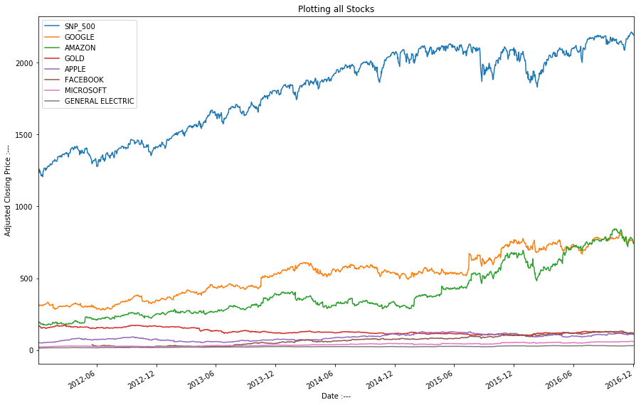

```python
#Printing df
axis = df.plot(figsize=(15, 10), title="Plotting all Stocks")

#Setting X-Label
axis.set_xlabel("Date :---")

#Setting Y-Label
axis.set_ylabel("Adjusted Closing Price :---")

plt.show()
```

# Plotting and Analysis:

## 1. Plot data

- Plot selected data
- Nomalize data
- Rolling mean
- Rolling standard deviation
- Bollinger bands
- Daily return

## 2. Further Analysis:

- Commulative return
- Creating portfolio
- Plotting portfolio statistics

```python
# Writing Utility functions



def symbol_to_path(symbol, base_dir="data"):

    """Return CSV file path given ticker symbol."""

    return os.path.join(base_dir, "{}.csv".format(str(symbol)))


def get_data(symbols, dates):

    """Read stock data (adjusted close) for given symbols from CSV files."""

    #Creating a DataFrame using 'Date' as Index values
    #Without this the Index will have parameters as 0,1,2...
    df = pd.DataFrame(index=dates)

    # Add SNP_500 for reference, if absent
    if 'SNP_500' not in symbols:
        symbols.insert(0, 'SNP_500')


    for symbol in symbols:

        #pd.read_csv : Reading the SNP_500.csv file
        #index_col : Date column in the csv file is used as index
        #parse_dates : Converting Dates present in the dataframe to be converted to Date-Time Index Objects
        #usecols : Using only 'Date' and 'Adj Close' columns and getting ride of others
        #na_values : to treat 'NaN' as Not-a-Number
        df_temp=pd.read_csv("Data/{}.csv".format(symbol), index_col='Date',parse_dates=True,usecols=['Date',
                                                                                                     'Adj Close']
                           ,na_values=['nan'])

        #Renaming 'Adj Close' column to their 'Stock symbol'
        df_temp = df_temp.rename(columns={'Adj Close': symbol})

        #Using default how='left'
        df = df.join(df_temp)

        #Taking SNP_500 as reference and dropping NaN values
        if symbol == 'SNP_500':
            df = df.dropna(subset=["SNP_500"])

    return df


def plot_data(df, title="Stock prices", xlabel="Date", ylabel="Price"):

    """Plot stock prices with a custom title and meaningful axis labels."""

    axis = df.plot(title=title, fontsize=12,figsize = (15,10))

    #Setting X-Label
    axis.set_xlabel(xlabel)

    #Setting Y-Label
    axis.set_ylabel(ylabel)
    plt.show()



def plot_selected(df, columns, start_index, end_index, title="Stock prices"):

    """Plot the desired columns over index values in the given range."""

    #Creating a DataFrame using 'Date' as Index values
    df_new = df.ix[start_index : end_index,columns]
    axis = df_new.plot(title=title,fontsize=10,figsize = (15,10))

    #Setting X-Label
    axis.set_xlabel("Date")

    #Setting Y-Label
    axis.set_ylabel("Price")
    plt.show()



def normalize_data(df):

    """Normalize data by uisng the first row of the dataframe"""

    return df/df.ix[0,:]



def get_rolling_mean(values, window):

    """Return rolling mean given values, using specified window size"""

    return pd.rolling_mean(values, window=window)



def get_rolling_std(values, window):

    """Return rolling standard deviation of given values, using specified window size"""

    return pd.rolling_std(values, window=window)



def get_bollinger_bands(rm, rstd):

    """Return upper lower bollinger bands."""

    upper_band = rm + rstd * 2
    lower_band = rm - rstd * 2
    return upper_band, lower_band



def compute_daily_return(df):

    daily_returns = (df / df.shift(1)) - 1
    daily_returns.ix[0, :] = 0
    return daily_returns[1:]



def cummulative_return(df):

    cummulative_return = (df.ix[-1] / df.ix[0]) - 1
    return cummulative_return



def find_alloc(df, alloc_func, num_symbols):

    # guess initial allocation
    allocgss = [0.166, 0.166, 0.166, 0.166, 0.166, 0.166, 0.166]

    # has to bound the allocations betwen 0 and 1. setting the min, max pair for each element in x
    bounds = [(0,1.0) for i in range(num_symbols)]

    # call optimizer to minimize alloc_function

    result = spo.minimize(alloc_func, allocgss, args=(df,), bounds=bounds, method='SLSQP',
                           options={'disp':True},
                            constraints=({ 'type': 'eq', 'fun': lambda inputs: 1.0 - np.sum(inputs)})).x

    return result


def alloc_function(alloc, df):

    trading_period_days = 252
    starting_value = 1000000

    #Normalize stock and apply allocation
    df_normalized = normalize_data(df)
    df_normalized_allocation = df_normalized * alloc

    # Calculate portfolio value by day
    starting_value = 1000000
    # normalize portfolio
    df_normed_alloc_value = df_normalized_allocation * starting_value
    portfolio_values = df_normed_alloc_value.sum(axis=1)


    # Portfolio value by day
    portfolio_val = pd.DataFrame()
    portfolio_val['portfolio_value'] = portfolio_values

    # Compute daily returns on the portfolio
    daily_returns_portfolio = compute_daily_return(portfolio_val)


    # Higher the sharp ratio the better (Reward / Risk) , so we should minimize the negative sharp ratio
    sharpe_ratio = -1 * np.sqrt(trading_period_days) * (daily_returns_portfolio.mean()/daily_returns_portfolio.std())
    return sharpe_ratio
```

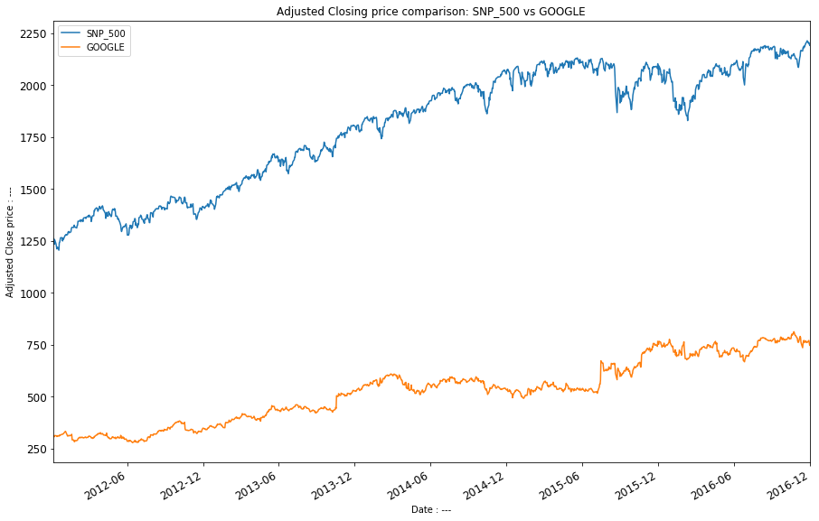

```python
# Defining Date Range using Pandas
dates = pd.date_range('2011-01-01', '2016-12-01')

# Choose stock symbols to read
symbols = ['GOOGLE', 'AMAZON', 'GOLD', 'APPLE', 'FACEBOOK', 'MICROSOFT', 'GENERAL ELECTRIC']

# Get stock data
df = get_data(symbols, dates)
df = df.sort_index(ascending=True, axis=0)

# Fill empty trade dates with forward filling dates first and then backward filling
df.fillna(method="ffill", inplace="True")
df.fillna(method="bfill", inplace="True")

#Plotting Adjusted Closing price comparison for SNP_500 and GOOGLE
plot_data(df[['SNP_500','GOOGLE']], title="Adjusted Closing price comparison: SNP_500 vs GOOGLE", xlabel='Date : ---', ylabel='Adjusted Close price : ---')
```

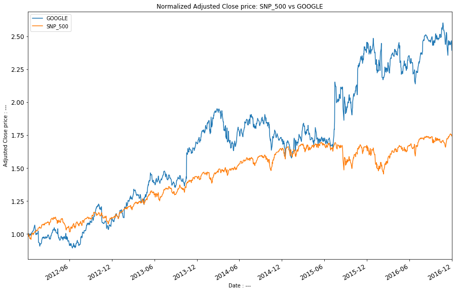

```python
#Normalize and plot few selected stocks : 'GOOGLE' and 'SNP_500'
plot_data(normalize_data(df[['GOOGLE','SNP_500']]), title="Normalized Adjusted Close price: SNP_500 vs GOOGLE",xlabel='Date : ---', ylabel='Adjusted Close price : ---')
```

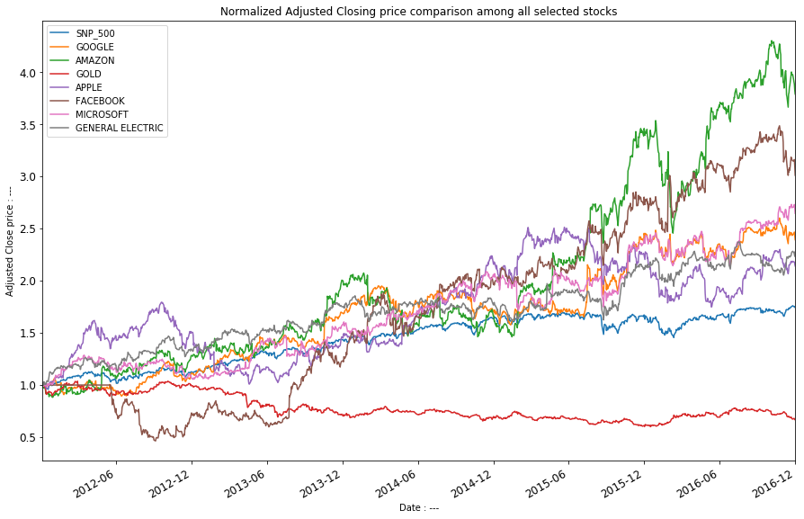

```python
#Normalize and plot the data all the stocks
plot_data(normalize_data(df), title="Normalized Adjusted Closing price comparison among all selected stocks", xlabel='Date : ---', ylabel='Adjusted Close price : ---')
```

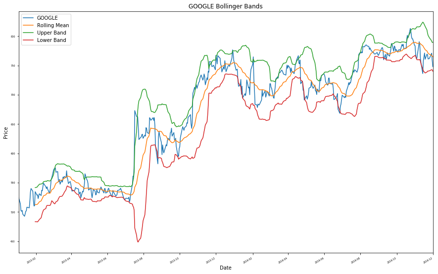

```python
#Compute Global Statistics

#Slicing by row and column
df_new = df.ix['2015-01-01':'2016-12-01',['GOOGLE', 'AMAZON', 'GOLD', 'APPLE', 'FACEBOOK', 'MICROSOFT', 'GENERAL ELECTRIC', 'SNP_500']]


# To Compute Bollinger Bands :---

# 1. Compute rolling mean
rm_SNP_500 = get_rolling_mean(df_new['GOOGLE'],window=20)

# 2. Compute rolling std
rstd_SNP_500 = get_rolling_std(df_new['GOOGLE'],window=20)

# 3. Compute upper and lower bollinger bands
upper_band, lower_band = get_bollinger_bands(rm_SNP_500, rstd_SNP_500)

#Plot GOOGLE's Bollinger Bands
ax = df_new['GOOGLE'].plot(title="GOOGLE Bollinger Bands", label='GOOGLE',fontsize=10,figsize = (15,10))
rm_SNP_500.plot(label='Rolling Mean', ax=ax ,fontsize=5)
upper_band.plot(label='Upper Band', ax=ax ,fontsize=5)
lower_band.plot(label='Lower Band', ax=ax ,fontsize=5)

#Add axis labels and legends
ax.set_xlabel("Date")
ax.set_ylabel("Price")
ax.legend(loc='upper left')
plt.figure(figsize=(40,10))
plt.show()
```

**NOTE:** The initial gap is due to the window size. As the window size is set to 20 so the rolling mean and the bollinger bands starts after 20 days.

# Computation of Daily Returns

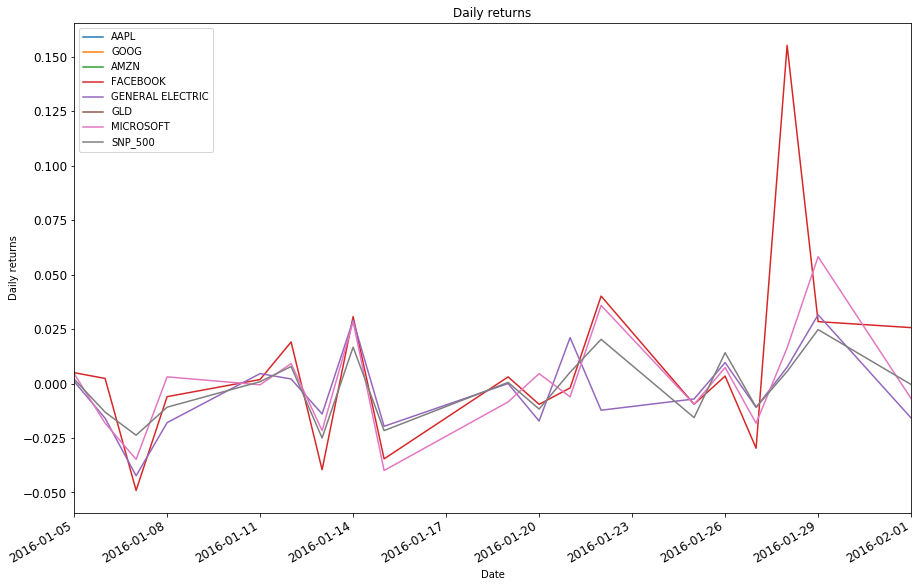

```python
#Compute and plot daily return for all stocks

daily_returns = compute_daily_return(df.ix['2016-01-01':'2016-02-01',['AAPL', 'GOOG', 'AMZN', 'FACEBOOK', 'GENERAL ELECTRIC','GLD' ,'MICROSOFT','SNP_500']])
plot_data(daily_returns, title="Daily returns", ylabel="Daily returns")
```

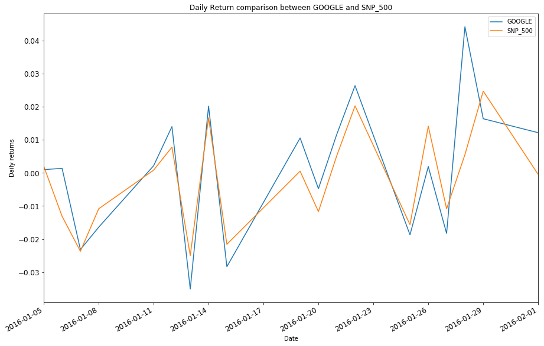

```python
#Compute and plot daily return for selected stocks compared to SNP_500

daily_returns = compute_daily_return(df.ix['2016-01-01':'2016-02-01',['GOOGLE', 'SNP_500']])
plot_data(daily_returns, title="Daily Return comparison between GOOGLE and SNP_500", ylabel="Daily returns")
```

```python
print "---- Printing Commulative Returns for all the stocks for the period between '2015-01-01' and '2016-12-01----"
print "\n"

for i in symbols:
    cret = cummulative_return(df_new[i])
    print "Commulative Return for "+ i +" is:"
    per = cret*100
    per = "%.2f" % per
    print str(per)+"%"
```

```
---- Printing Commulative Returns for all the stocks for the period between '2015-01-01' and '2016-12-01----


Commulative Return for SNP_500 is:
6.46%
Commulative Return for GOOGLE is:
42.51%
Commulative Return for AMAZON is:
141.04%
Commulative Return for GOLD is:
-2.23%
Commulative Return for APPLE is:
4.12%
Commulative Return for FACEBOOK is:
46.72%
Commulative Return for MICROSOFT is:
33.62%
Commulative Return for GENERAL ELECTRIC is:
32.64%
```

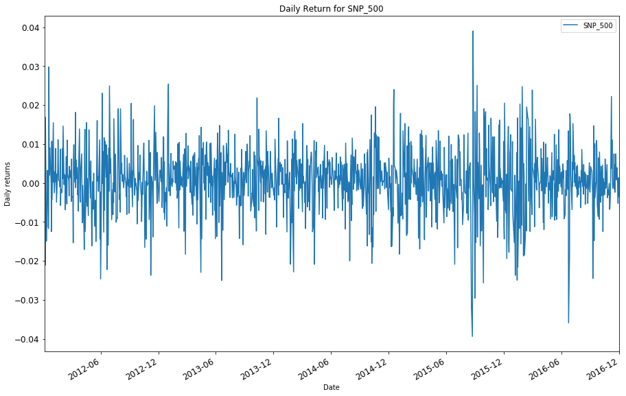

```python
#Compute and plot daily return for SNP_500
daily_returns = compute_daily_return(df[['SNP_500']])
plot_data(daily_returns, title="Daily Return for SNP_500", ylabel="Daily returns")
```

[figure not shown]

```python
#Compute and plot daily return for SNP_500
daily_returns_GOOG = compute_daily_return(df[['GOOGLE']])
plot_data(daily_returns, title="Daily Return for GOOGLE", ylabel="Daily returns")
```

```python
#Compute Mean, Stndard Deviation and Kurtosis for SNP_500
print "Mean, Stndard Deviation and Kurtosis for SNP_500 : -----"
mean = daily_returns.mean()
print "Mean =", mean
std = daily_returns.std()
print "Standard Deviation =", std
kur = daily_returns.kurtosis()
print "Kurtosis =", kur

#Compute Mean, Stndard Deviation and Kurtosis for GOOGLE
print "Mean, Stndard Deviation and Kurtosis for GOOGLE : -----"
mean = daily_returns_GOOG.mean()
print "Mean =", mean
std = daily_returns_GOOG.std()
print "Standard Deviation =", std
kur = daily_returns_GOOG.kurtosis()
print "Kurtosis =", kur
```

```
Mean, Stndard Deviation and Kurtosis for SNP_500 : -----
Mean = SNP_500    0.000476
dtype: float64
Standard Deviation = SNP_500    0.008204
dtype: float64
Kurtosis = SNP_500    1.891211
dtype: float64
Mean, Stndard Deviation and Kurtosis for GOOGLE : -----
Mean = GOOGLE    0.000802
dtype: float64
Standard Deviation = GOOGLE    0.014717
dtype: float64
Kurtosis = GOOGLE    19.52001
dtype: float64
```

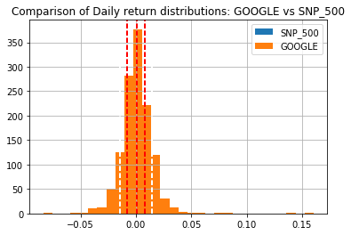

```python
#Plot histogram for multiple stocks on the same chart - GOOGLE and SNP_500

dr_hist = compute_daily_return(df[['SNP_500', 'GOOGLE']])
dr_hist['SNP_500'].hist(bins=30 , label ="SNP_500",)
dr_hist['GOOGLE'].hist(bins=30 , label ="GOOGLE")
plt.legend(loc='upper right')
plt.title('Comparison of Daily return distributions: GOOGLE vs SNP_500')
GOOG_mean = dr_hist['GOOGLE'].mean()
SNP_mean = dr_hist['SNP_500'].mean()
GOOG_STD = dr_hist['GOOGLE'].std()
SNP_std = dr_hist['SNP_500'].std()
plt.axvline(GOOG_mean,color='w',linestyle='dashed',linewidth=2)
plt.axvline(SNP_mean,color='r',linestyle='dashed',linewidth=2)
plt.axvline(GOOG_STD,color='w',linestyle='dashed',linewidth=2)
plt.axvline(-GOOG_STD,color='w',linestyle='dashed',linewidth=2)
plt.axvline(SNP_std,color='r',linestyle='dashed',linewidth=2)
plt.axvline(-SNP_std,color='r',linestyle='dashed',linewidth=2)
plt.show()
```

```
Beta GOOG = 1.00683512076
Alpha GOOG = 0.00032240857603
```

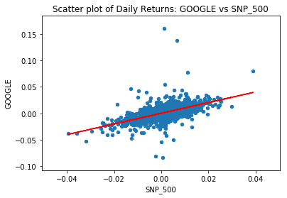

```python
#Scatter plots and co-relation
dr_scatter = compute_daily_return(df)

#Scatter plot SNP_500 vs GOOGLE
dr_scatter.plot(kind='scatter',x='SNP_500',y='GOOGLE')

#Fitting line with beta and alpha for GOOGLE
beta_GOOG, alpha_GOOG = np.polyfit(dr_scatter['SNP_500'],dr_scatter['GOOGLE'],1)
plt.plot(daily_returns['SNP_500'],beta_GOOG*daily_returns['SNP_500'] + alpha_GOOG, '-',color='r')
plt.title('Scatter plot of Daily Returns: GOOGLE vs SNP_500')
print "Beta GOOG =", beta_GOOG
print "Alpha GOOG =", alpha_GOOG
```

```
Beta GOLD =  -0.00159911167288
Alpha GOLD =  -0.000265817421543
```

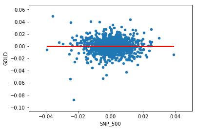

```python
#Scatter plot SNP_500 vs GLD
dr_scatter.plot(kind='scatter',x='SNP_500',y='GOLD')

#Fitting line with beta and alpha for GLD
beta_GOLD, alpha_GOLD = np.polyfit(dr_scatter['SNP_500'],dr_scatter['GOLD'],1)
plt.plot(daily_returns['SNP_500'],beta_GOLD*daily_returns['SNP_500'] + alpha_GOLD, '-',color='r')

print "Beta GOLD = ", beta_GOLD
print "Alpha GOLD = ", alpha_GOLD
```

```python
#Calculate Co-orelation coefficient
display(dr_scatter.corr(method='pearson'))
```

|  | SNP_500 | GOOGLE | AMAZON | GOLD | APPLE | FACEBOOK | MICROSOFT | GENERAL ELECTRIC |
| --- | --- | --- | --- | --- | --- | --- | --- | --- |
| SNP_500 | 1.000000 | 0.561288 | 0.494226 | -0.001239 | 0.499828 | 0.317453 | 0.613608 | 0.725937 |
| GOOGLE | 0.561288 | 1.000000 | 0.486442 | -0.040297 | 0.317679 | 0.312197 | 0.428412 | 0.381830 |
| AMAZON | 0.494226 | 0.486442 | 1.000000 | -0.023005 | 0.236503 | 0.296935 | 0.351674 | 0.321093 |
| GOLD | -0.001239 | -0.040297 | -0.023005 | 1.000000 | 0.028924 | -0.023161 | -0.014787 | 0.006026 |
| APPLE | 0.499828 | 0.317679 | 0.236503 | 0.028924 | 1.000000 | 0.193689 | 0.324849 | 0.298751 |
| FACEBOOK | 0.317453 | 0.312197 | 0.296935 | -0.023161 | 0.193689 | 1.000000 | 0.210004 | 0.208330 |
| MICROSOFT | 0.613608 | 0.428412 | 0.351674 | -0.014787 | 0.324849 | 0.210004 | 1.000000 | 0.402501 |
| GENERAL ELECTRIC | 0.725937 | 0.381830 | 0.321093 | 0.006026 | 0.298751 | 0.208330 | 0.402501 | 1.000000 |

```python
#### RUN PORTFOLIO STATS


# Define a date range
dates = pd.date_range('2014-12-01', '2016-12-01')

# Choose stock symbols to read
symbols = ['GOOGLE', 'AMAZON', 'GOLD', 'APPLE', 'FACEBOOK', 'MICROSOFT', 'GENERAL ELECTRIC']

# Get stock data
df = get_data(symbols, dates)

# Fill empty trade dates with forward filling dates first and then backward filling
df.fillna(method="ffill", inplace="True")
df.fillna(method="bfill", inplace="True")

df_port = df.drop('SNP_500', axis=1)

# Normalize stock prices
df_normalized = normalize_data(df_port)
print "\n"
print "Normalized: "
display(df_normalized.head())
print "\n"
```

```
Normalized:
```

|  | GOOGLE | AMAZON | GOLD | APPLE | FACEBOOK | MICROSOFT | GENERAL ELECTRIC |
| --- | --- | --- | --- | --- | --- | --- | --- |
| 2014-12-01 | 1.000000 | 1.000000 | 1.000000 | 1.000000 | 1.000000 | 1.000000 | 1.000000 |
| 2014-12-02 | 0.999906 | 1.000951 | 0.987648 | 0.996176 | 1.004794 | 0.996709 | 1.001153 |
| 2014-12-03 | 0.995354 | 0.970859 | 0.997856 | 1.007474 | 0.997071 | 0.988894 | 1.013835 |
| 2014-12-04 | 1.006576 | 0.972178 | 0.993995 | 1.003650 | 1.001864 | 1.004525 | 1.002690 |
| 2014-12-05 | 0.984002 | 0.958988 | 0.981558 | 0.999392 | 1.016778 | 0.995886 | 0.999616 |

```python
# Portfolio allocation for each stock
allocation = [0.166, 0.166, 0.166, 0.166, 0.166, 0.166, 0.166]
df_allocation = df_normalized * allocation
print "Allocated: "
display(df_allocation.head())
print "\n"
```

```
Allocated:
```

|  | GOOGLE | AMAZON | GOLD | APPLE | FACEBOOK | MICROSOFT | GENERAL ELECTRIC |
| --- | --- | --- | --- | --- | --- | --- | --- |
| 2014-12-01 | 0.166000 | 0.166000 | 0.166000 | 0.166000 | 0.166000 | 0.166000 | 0.166000 |
| 2014-12-02 | 0.165984 | 0.166158 | 0.163950 | 0.165365 | 0.166796 | 0.165454 | 0.166191 |
| 2014-12-03 | 0.165229 | 0.161163 | 0.165644 | 0.167241 | 0.165514 | 0.164156 | 0.168297 |
| 2014-12-04 | 0.167092 | 0.161382 | 0.165003 | 0.166606 | 0.166309 | 0.166751 | 0.166447 |
| 2014-12-05 | 0.163344 | 0.159192 | 0.162939 | 0.165899 | 0.168785 | 0.165317 | 0.165936 |

```python
# Starting value for each stock -- dividing 1 million equally among all stocks

starting_value = 1000000
df_values = df_allocation * starting_value
print "Portfolio Stock value : "
display(df_values.head())
print "\n"
```

```
Portfolio Stock value :
```

|  | GOOGLE | AMAZON | GOLD | APPLE | FACEBOOK | MICROSOFT | GENERAL ELECTRIC |
| --- | --- | --- | --- | --- | --- | --- | --- |
| 2014-12-01 | 166000.000000 | 166000.000000 | 166000.000000 | 166000.000000 | 166000.000000 | 166000.000000 | 166000.000000 |
| 2014-12-02 | 165984.450553 | 166157.851742 | 163949.558296 | 165365.252335 | 166795.741246 | 165453.721704 | 166191.379370 |
| 2014-12-03 | 165228.776100 | 161162.576687 | 165644.021279 | 167240.637232 | 165513.712823 | 164156.321562 | 168296.682013 |
| 2014-12-04 | 167091.544313 | 161381.530178 | 165003.252462 | 166605.889567 | 166309.454069 | 166751.132657 | 166446.574596 |
| 2014-12-05 | 163344.253836 | 159191.965736 | 162938.580152 | 165899.018405 | 168785.093257 | 165317.148527 | 165936.197784 |

```python
# Portfolio value by day
portfolio_values = pd.DataFrame()
portfolio_values['portfolio_value'] = df_values.sum(axis=1)
print "Portfolio values by day: "
display(portfolio_values.head())
print "\n"
```

```
Portfolio values by day:
```

|  | portfolio_value |
| --- | --- |
| 2014-12-01 | 1.162000e+06 |
| 2014-12-02 | 1.159898e+06 |
| 2014-12-03 | 1.157243e+06 |
| 2014-12-04 | 1.159589e+06 |
| 2014-12-05 | 1.151412e+06 |

```python
# Compute daily returns on the portfolio
daily_returns_portfolio = compute_daily_return(portfolio_values)
print "Portfolio Daily returns: "
display(daily_returns_portfolio.head())
print "\n"
```

```
Portfolio Daily returns:
```

|  | portfolio_value |
| --- | --- |
| 2014-12-02 | -0.001809 |
| 2014-12-03 | -0.002289 |
| 2014-12-04 | 0.002028 |
| 2014-12-05 | -0.007052 |
| 2014-12-08 | -0.007373 |

```
Following is the plotted portfolio statistics
```

[figure not shown]

```python
### Plotting Portfolios statistics

print "Following is the plotted portfolio statistics"
print "\n"
plot_data(portfolio_values, title="Portfolio daily values starting with 10000000", xlabel="Date", ylabel="Price")
```

```
Follwoing is the portfolio value normalzed plot
```

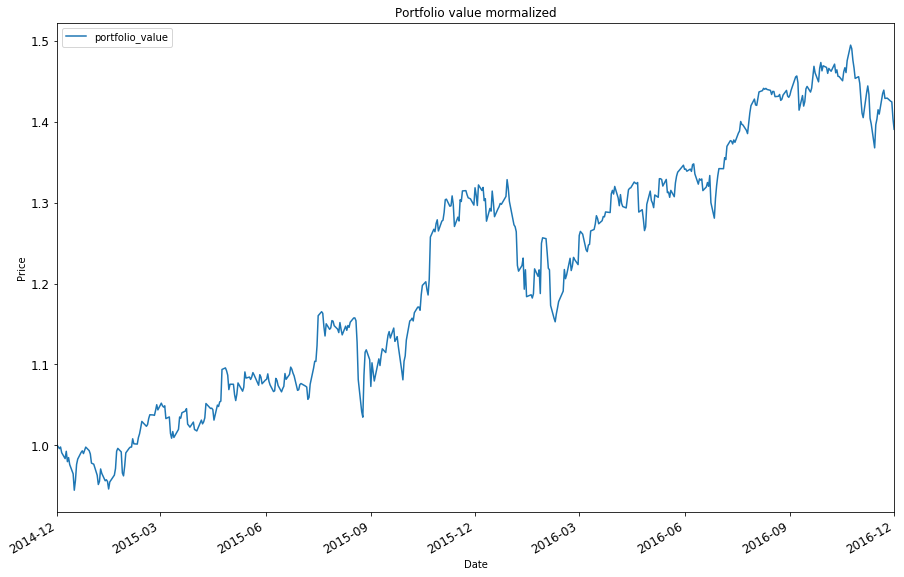

```python
print "Follwoing is the portfolio value normalzed plot"
print "\n"
plot_data(normalize_data(portfolio_values), title="Portfolio value mormalized", xlabel="Date", ylabel="Price")
```

```
Following is the portfolio value Normalized plot vs Normalized SNP_500
```

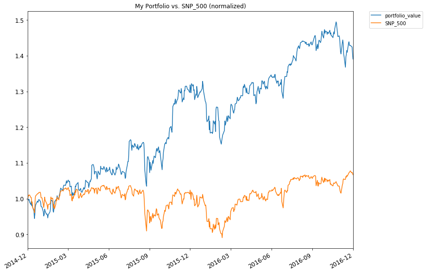

```python
print "\n"
print "Following is the portfolio value Normalized plot vs Normalized SNP_500"

normalize_data(portfolio_values).plot(title="My Portfolio vs. SNP_500 (normalized)",fontsize=12,figsize=(12,10), label="My Portfolio")
normalize_data(df)['SNP_500'].plot(title="My Portfolio vs. SNP_500 (normalized)",fontsize=12,figsize=(12,10), label="SNP_500")
plt.legend(bbox_to_anchor=(1.05, 1), loc=2, borderaxespad=0.)
plt.show()
```

```python
print "Fund allocations by symbol: symbols = {},  Allocation = {}".format([x for x in symbols if x != 'SNP_500'], allocation)
print "\n"

# Cumulative return
cr = cummulative_return(portfolio_values)
print "Cumulative return: ", cr

# Average daily return
print "Average daily return: ", daily_returns_portfolio.mean()


# standard deviation
print "Daily standard deviation: ", daily_returns_portfolio.std()


# Sharpe ratio
Sharpe_ratio = np.sqrt(252) * (daily_returns_portfolio.mean())/daily_returns_portfolio.std()
print "Sharpe ratio: ", Sharpe_ratio
print "\n"
```

```
Fund allocations by symbol: symbols = ['GOOGLE', 'AMAZON', 'GOLD', 'APPLE', 'FACEBOOK', 'MICROSOFT', 'GENERAL ELECTRIC'],  Allocation = [0.166, 0.166, 0.166, 0.166, 0.166, 0.166, 0.166]


Cumulative return:  portfolio_value    0.390784
dtype: float64
Average daily return:  portfolio_value    0.000713
dtype: float64
Daily standard deviation:  portfolio_value    0.010947
dtype: float64
Sharpe ratio:  portfolio_value    1.03411
dtype: float64
```

# Optimizing the Portfolio :

- Optimizing the Portfolio by optimizing or miminimizing the negative sharpe ratio
- Plotting optimal portfolio statistics
- Scatter plot, co-relation between my portfolio daily return and SNP_500 daily return, Beta value to see how reactive is my optimized portfolio compared to the market, alpha value to see how well it performs campared to the market
- Histogram

```python
dates = pd.date_range('2014-12-01', '2016-12-01') # Define a date range
symbols = ['GOOGLE', 'AMAZON', 'GOLD', 'APPLE', 'FACEBOOK', 'MICROSOFT', 'GENERAL ELECTRIC'] # Choose stock symbols to read
df = get_data(symbols, dates) # Get stock data
df = df.sort_index(ascending=True, axis=0)
print "\n"
print "List of stocks"
print symbols
print "\n"

df_port = df.drop('SNP_500', axis=1) # Drop the SNP_500 index
df_port.fillna(method="ffill", inplace="True") # Forward fill empty trade dates
df_port.fillna(method="bfill", inplace="True") # backfill empty trade dates

num_symbols = len([x for x in symbols if x != 'SNP_500'])

#Try to get all optimal allocations
optimal_alloc = find_alloc(df_port, alloc_function, num_symbols)

print "\n"
print "Optimal Allocations:"
print "\n"
print ("GOOGLE: {0:.3f}".format(optimal_alloc[0]))
print ("AMAZON: {0:.3f}".format(optimal_alloc[1]))
print ("GOLD: {0:.3f}".format(optimal_alloc[2]))
print ("APPLE: {0:.3f}".format(optimal_alloc[3]))
print ("FACEBOOK: {0:.3f}".format(optimal_alloc[4]))
print ("MICROSOFT: {0:.3f}".format(optimal_alloc[5]))
print ("GENERAL ELECTRIC: {0:.3f}".format(optimal_alloc[6]))
print "\n"
```

```
List of stocks
['SNP_500', 'GOOGLE', 'AMAZON', 'GOLD', 'APPLE', 'FACEBOOK', 'MICROSOFT', 'GENERAL ELECTRIC']


Optimization terminated successfully.    (Exit mode 0)
            Current function value: portfolio_value   -1.448061
dtype: float64
            Iterations: 5
            Function evaluations: 46
            Gradient evaluations: 5


Optimal Allocations:


GOOGLE: 0.000
AMAZON: 0.914
GOLD: 0.000
APPLE: 0.000
FACEBOOK: 0.086
MICROSOFT: 0.000
GENERAL ELECTRIC: 0.000
```

```
[0.0, 0.914, 0.0, 0.0, 0.086, 0.0, 0.0]




Following is the plotted optimal portfolio statistics:
```

[figure not shown]

```python
#### Plotting optimal Portfolio statistics


# Normalize stock prices
df_normalized = normalize_data(df_port)
print "\n"



# Portfolio allocation for each stock
allocation = []
for i in range(len(optimal_alloc)):
    allocation.append(round(optimal_alloc[i],3))
print allocation
print "\n"


df_allocation = df_normalized * allocation


# starting value for each stock -- dividing 1 million equally among all stocks

starting_value = 1000000
df_values = df_allocation * starting_value

# Portfolio value by day
portfolio_values = pd.DataFrame()
portfolio_values['portfolio_value'] = df_values.sum(axis=1)

# Compute daily returns on the portfolio
daily_returns_portfolio = compute_daily_return(portfolio_values)


print "\n"
print "Following is the plotted optimal portfolio statistics:"
print "\n"
plot_data(portfolio_values, title="Optimzed Portfolio daily values starting with 10000000", xlabel="Date", ylabel="Price")
```

```
Following is the optimal portfolio value normalized plot
```

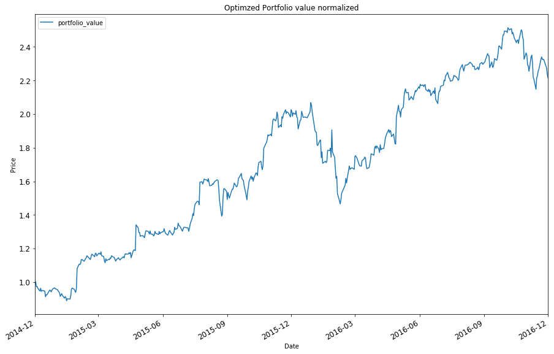

```python
print "\n"
print "Following is the optimal portfolio value normalized plot"
print "\n"
plot_data(normalize_data(portfolio_values), title="Optimzed Portfolio value normalized", xlabel="Date", ylabel="Price")
```

```
Following is the optimal portfolio value normalized plot vs normalized SNP_500
```

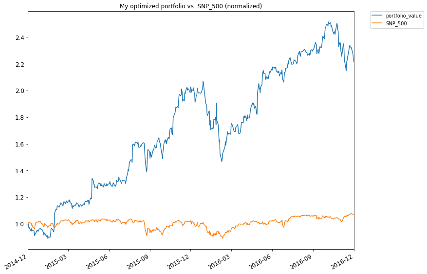

```python
print "\n"
print "Following is the optimal portfolio value normalized plot vs normalized SNP_500"
print "\n"
normalize_data(portfolio_values).plot(title="My optimized portfolio vs. SNP_500 (normalized)",fontsize=12,figsize=(12,10), label="my portfolio")
normalize_data(df)['SNP_500'].plot(title="My optimized portfolio vs. SNP_500 (normalized)",fontsize=12,figsize=(12,10), label="SNP_500")
plt.legend(bbox_to_anchor=(1.05, 1), loc=2, borderaxespad=0.)
plt.show()
```

```python
# Cumulative return
print "\n"
print "Fund allocations by symbol: symbols = {},  Allocation = {}".format([x for x in symbols if x != 'SNP_500'], allocation)
print "\n"
cr = cummulative_return(portfolio_values)
print "Cumulative Return: ", cr

# Average daily return
print "Average Daily Return: ", daily_returns_portfolio.mean()

# standard deviation
print "Daily Standard Deviation: ", daily_returns_portfolio.std()

# Sharpe ratio

Sharpe_ratio = np.sqrt(252) * (daily_returns_portfolio.mean())/daily_returns_portfolio.std()
print "Sharpe Ratio: ", Sharpe_ratio
print "\n"
```

```
Fund allocations by symbol: symbols = ['GOOGLE', 'AMAZON', 'GOLD', 'APPLE', 'FACEBOOK', 'MICROSOFT', 'GENERAL ELECTRIC'],  Allocation = [0.0, 0.914, 0.0, 0.0, 0.086, 0.0, 0.0]


Cumulative Return:  portfolio_value    1.216763
dtype: float64
Average Daily Return:  portfolio_value    0.00176
dtype: float64
Daily Standard Deviation:  portfolio_value    0.019296
dtype: float64
Sharpe Ratio:  portfolio_value    1.448061
dtype: float64
```

```
Scaller plot between my optimized portfolio and SNP_500
```

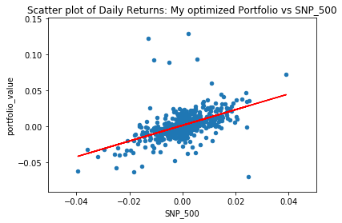

```
Beta APPLE = 1.08940744037
Alpha APPLE = 0.00157438228967


Aplha value is positive, so in an average my optimized portfolio is performing little bit better than the SNP_500


Co-relation between my optimzed portfolio and the market (SNP_500):


                  SNP_500  portfolio_value
SNP_500          1.000000         0.518127
portfolio_value  0.518127         1.000000
```

```python
print "\n"
print "Scaller plot between my optimized portfolio and SNP_500"

daily_return_all = compute_daily_return(df)
dr_scatter = pd.concat([daily_return_all, daily_returns_portfolio], axis=1)
dr_scatter.plot(kind='scatter',x='SNP_500',y='portfolio_value')

#Fitting line with beta and alpha for Portfolio and printring Beta and alpha

beta_portfolio, alpha_portfolio = np.polyfit(dr_scatter['SNP_500'],dr_scatter['portfolio_value'],1)
plt.plot(dr_scatter['SNP_500'],beta_portfolio*dr_scatter['SNP_500'] + alpha_portfolio, '-',color='r')
plt.title('Scatter plot of Daily Returns: My optimized Portfolio vs SNP_500')
plt.show()
print "Beta APPLE = " +str(beta_portfolio)
print "Alpha APPLE = " +str(alpha_portfolio)


print "\n"
if float(alpha_portfolio) > 0.00:
    print "Aplha value is positive, so in an average my optimized portfolio is performing little bit better than the SNP_500"
elif float(alpha_portfolio) < 0.00:
    print "Alpha is negative, so in an average my optimized portfolio is returning little bit less compared to the market"
else:
    pass

print "\n"

#Calculate Co-orelation Coefficient
print "Co-relation between my optimzed portfolio and the market (SNP_500):"
print "\n"
print dr_scatter[['SNP_500', 'portfolio_value']].corr(method='pearson')


print "\n"
```

```
Mean for my optimized portfolio= 0.00176019609996
Standard Deviation for my portfolio= 0.0192963185385
Kurtosis for my optimized portfolio = 9.53083492677
```

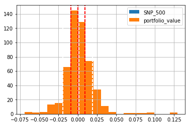

```python
#Plot histogram for my portfolio and campare with SNP_500

#Compute Mean and Standard Deviation for my portfolio
mean = dr_scatter['portfolio_value'].mean()
print "Mean for my optimized portfolio=", mean

mean_SNP = dr_scatter['SNP_500'].mean()

std = dr_scatter['portfolio_value'].std()
print "Standard Deviation for my portfolio=", std

std_SNP = dr_scatter['SNP_500'].std()


#Compute Kurtosis
kur = dr_scatter['portfolio_value'].kurtosis()
print "Kurtosis for my optimized portfolio =", kur

dr_scatter['SNP_500'].hist(bins=20 , label ="SNP_500")
dr_scatter['portfolio_value'].hist(bins=20 , label ="portfolio_value")
plt.legend(loc='upper right')



#Draw Standard Deviation and Mean in the histogram
plt.axvline(mean,color='w',linestyle ='dashed',linewidth=2)
plt.axvline(std,color='w',linestyle ='dashed',linewidth=2)
plt.axvline(-std,color='w',linestyle ='dashed',linewidth=2)

plt.axvline(mean_SNP,color='r',linestyle ='dashed',linewidth=2)
plt.axvline(std_SNP,color='r',linestyle ='dashed',linewidth=2)
plt.axvline(-std_SNP,color='r',linestyle ='dashed',linewidth=2)

plt.show()
```

# STOCK PRICE PREDICTION INTERFACE --- KNN REGRESSION

```
Score on training data for GOOGLE :0.98
Score on test data for GOOGLE : -24.80
The prediction on the test dataset 1 days after the training date for GOOGLE is +/- 10.763% compared to the actual values


Score on training data for APPLE :0.96
Score on test data for APPLE : -0.73
The prediction on the test dataset 1 days after the training date for APPLE is +/- 2.57% compared to the actual values


Score on training data for GOLD :0.99
Score on test data for GOLD : 0.66
The prediction on the test dataset 1 days after the training date for GOLD is +/- 1.427% compared to the actual values


Score on training data for AMAZON :0.97
Score on test data for AMAZON : -16.73
The prediction on the test dataset 1 days after the training date for AMAZON is +/- 12.652% compared to the actual values


Score on training data for FACEBOOK :0.98
Score on test data for FACEBOOK : -15.85
The prediction on the test dataset 1 days after the training date for FACEBOOK is +/- 7.156% compared to the actual values


Score on training data for GENERAL ELECTRIC :0.95
Score on test data for GENERAL ELECTRIC : -2.58
The prediction on the test dataset 1 days after the training date for GENERAL ELECTRIC is +/- 2.817% compared to the actual values


Score on training data for MICROSOFT :0.99
Score on test data for MICROSOFT : -74.57
The prediction on the test dataset 1 days after the training date for MICROSOFT is +/- 11.645% compared to the actual values


The predicted stockprice for GOOGLE on 2015-12-02 : [ 658.01370004]
The predicted stockprice for AMAZON on 2015-12-02 : [ 578.93439793]
The predicted stockprice for FACEBOOK on 2015-12-02 : [ 97.6052375]
The predicted stockprice for GENERAL ELECTRIC on 2015-12-02 : [ 28.40312533]
The predicted stockprice for GOLD on 2015-12-02 : [ 104.73709378]
The predicted stockprice for MICROSOFT on 2015-12-02 : [ 46.71084242]
The predicted stockprice for APPLE on 2015-12-02 : [ 113.15154651]
```

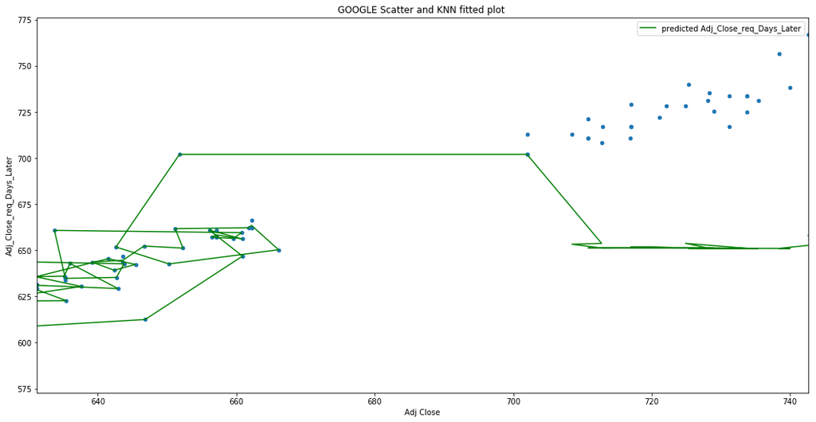

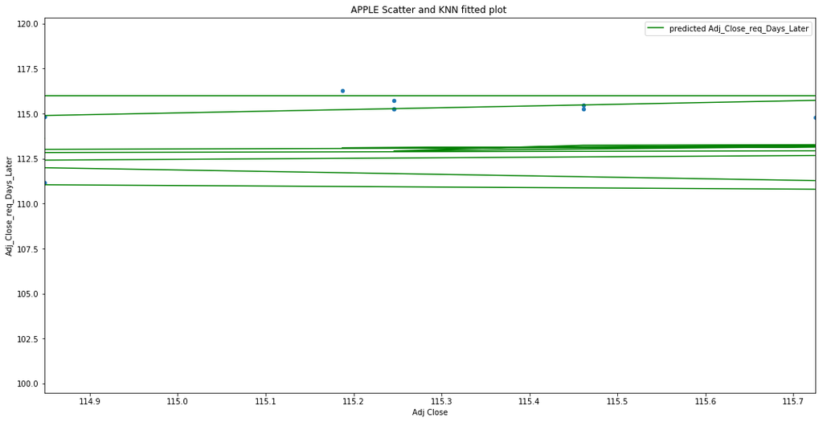

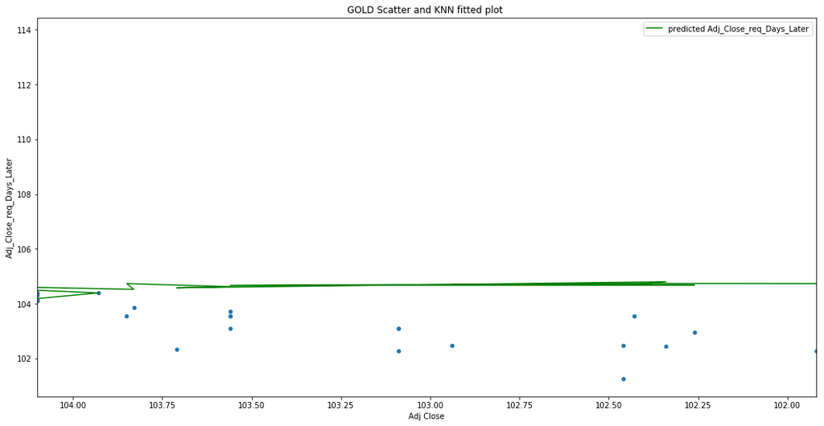

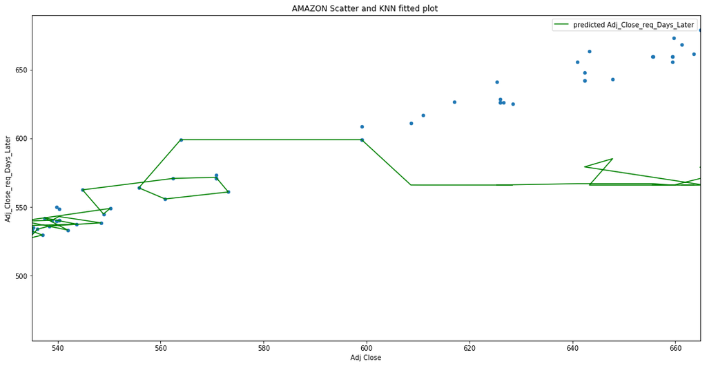

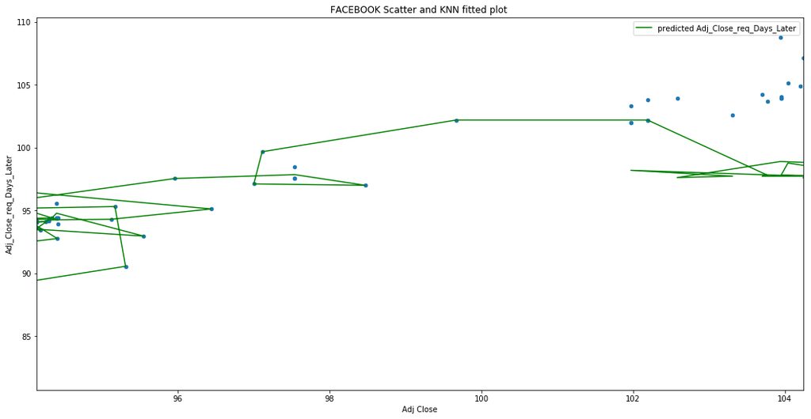

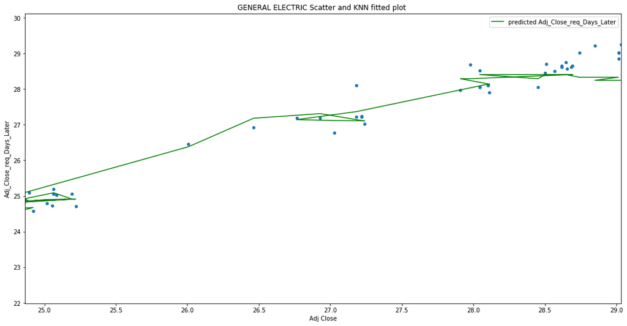

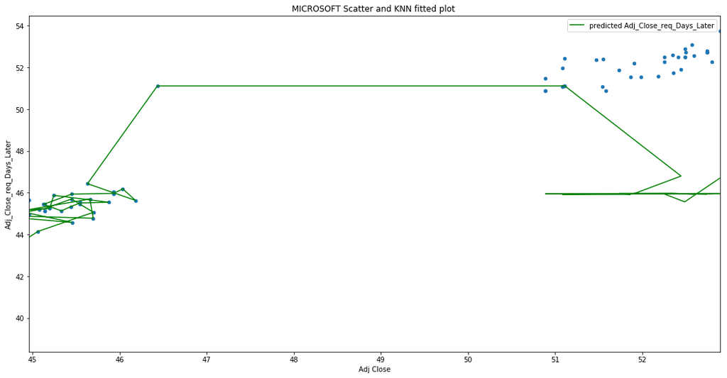

```python
from sklearn.linear_model import LinearRegression
from sklearn.neighbors import KNeighborsRegressor
from sklearn.metrics import mean_squared_error
from sklearn.preprocessing import PolynomialFeatures
from sklearn.pipeline import Pipeline
from sklearn.ensemble.forest import RandomForestRegressor
from sklearn.metrics import make_scorer
from sklearn.grid_search import GridSearchCV, RandomizedSearchCV
from sklearn.metrics import r2_score
from sklearn.cross_validation import ShuffleSplit
from sklearn.preprocessing import StandardScaler
from sklearn.preprocessing import normalize
import time, os
from datetime import datetime as dt
os.environ['TZ']='UTC'
from datetime import date, datetime



def symbol_to_path(symbol, base_dir="Data"):
    """Return CSV file path given ticker symbol."""
    return os.path.join(base_dir, "{}.csv".format(str(symbol)))

def get_data(symbol, dates):
    df = pd.DataFrame(index=dates)
    df_temp = pd.read_csv("Data/{}.csv".format(symbol), index_col='Date',parse_dates=True,usecols=['Date','Open', 'High', 'Low', 'Close', 'Volume', 'Adj Close']
                           ,na_values=['nan'])
    df = df.join(df_temp) #use default how='left'
    df.fillna(method="ffill", inplace="True") # Forward fill empty trade dates
    df.fillna(method="bfill", inplace="True") # backfill empty trade dates
    return df


def plot_data(df, title="Stock prices", xlabel="Date", ylabel="Price"):
    ax = df.plot(title=title, figsize=(12,10), fontsize=12)
    ax.set_xlabel(xlabel)
    ax.set_ylabel(ylabel)
    plt.show()


#Function for gridsearch for regression to find the best tuned regressor

def gridsearch(clf, parameters, scorer, X_train, y_train):
    #print "Performing Gradient Boosting Randomized gridsearch"
    cv = ShuffleSplit(X_train.shape[0], n_iter=10, test_size=0.25, random_state=0)
    n_iter_search = 8
    grid_obj = RandomizedSearchCV(estimator=clf, param_distributions=parameters, n_iter=n_iter_search, scoring=scorer, cv=cv)
    #print "Done with Gridsearch"
    grid_obj = grid_obj.fit(X_train, y_train)
    clf_out = grid_obj.best_estimator_
    return clf_out


def train_regressor(start_date, end_date, stock_list, days_shift):
    dates = pd.date_range(start_date, end_date)


    #Setting the variables to pick the indices for the training and test datasets, 70%-30% test train split

    date_format = "%Y-%m-%d"
    a = datetime.strptime(start_date, date_format)
    b = datetime.strptime(end_date, date_format)
    delta = b - a
    num_days = delta.days
    train_num = int(0.7*num_days)

     #Accumulating the data for each stock in a dictionary using get_data utility function

    symbols = stock_list

    d = {}
    for name in symbols:
        d[name] = get_data(name, dates)
        d[name] = d[name].sort_index(ascending=True, axis=0)

    # Add new column to view Adj Close 7 days later (target column for training/ testing the regression model)


    for key in d:
        d[key]['Adj_Close_req_Days_Later'] = d[key]['Adj Close']
        d[key]['Adj_Close_req_Days_Later'] = d[key]['Adj_Close_req_Days_Later'].shift(-days_shift)
        d[key].fillna(method="ffill", inplace="True") # Forward fill empty trade dates
        d[key].fillna(method="bfill", inplace="True") # backfill empty trade dates

    #Initializing the KNN Regressor
    regr_orig = KNeighborsRegressor()

    lrg_train = {}
    lrg_test  = {}

    for key in d:
        scaler = StandardScaler()
        X_train = d[key].iloc[0:train_num,:-1]
        scaler.fit(d[key].iloc[0:,:-1])
        X_train = scaler.transform(X_train)
        y_train = d[key].iloc[0:train_num, -1]
        X_test = d[key].iloc[train_num:num_days,:-1]
        X_test = scaler.transform(X_test)
        y_test = d[key].iloc[train_num:num_days, -1]



        # Perform gridsearch to find the most optimal hyperparameters for the Linear Regression algorithm


        params = {'n_neighbors': range(1, 50, 5),
                  'leaf_size': range(1, 50, 5),
                  'algorithm' : ['auto', 'ball_tree', 'kd_tree', 'brute'] ,
                  'weights': ['uniform', 'distance']}

        scorer = make_scorer(r2_score)

        regr = gridsearch(regr_orig, params, scorer, X_train, y_train)


        lrg_train[key] = regr.fit(X_train, y_train)

        a = key+"_val"

        lrg_train[a] = scaler.transform(d[key].iloc[(num_days-1):num_days,:-1])

        print "Score on training data for "+key+" :%.2f" % r2_score(y_train, lrg_train[key].predict(X_train))
        print "Score on test data for "+key+" : %.2f" % r2_score(y_test, lrg_train[key].predict(X_test))

        X = scaler.transform(d[key].iloc[0:,:-1])
        d[key]['Predicted'] = lrg_train[key].predict(X)



        #Scatter plot on trained data

        ax = d[key].iloc[0:num_days].plot.scatter(x='Adj Close', y='Adj_Close_req_Days_Later')
        d[key].iloc[0:num_days].plot(x='Adj Close',y='Predicted',color='green',ax=ax,label='predicted Adj_Close_req_Days_Later'
                               ,figsize=(18,9),title = key+' Scatter and KNN fitted plot ')

        #Prediction +/- percentage on the test data

        y_diff = ((lrg_train[key].predict(X_test) - y_test)/y_test)*100
        y_diff = y_diff.abs()
        row_cnt = y_diff.shape[0]
        percent_error = round((y_diff.sum(axis=0))/row_cnt,3)
        print "The prediction on the test dataset "+str(days_shift)+" days after the training date for "+key+" is +/- "+str(percent_error)+"% compared to the actual values"
        print "\n"


    return lrg_train

def query_regressor(train_start, train_end, date_predict, stock_list):


    date_format = "%Y-%m-%d"
    a = datetime.strptime(train_end, date_format)
    b = datetime.strptime(date_predict, date_format)
    delta = b - a
    shift = delta.days

    regressor = train_regressor(train_start, train_end, stock_list, shift)
    for key in regressor:
        if key in stock_list:
            to_pred = key+"_val"
            predicted = regressor[key].predict(regressor[to_pred])
            print "The predicted stockprice for "+str(key)+" on "+str(date_predict)+" : "+str(predicted)
        else:
            pass


if __name__ == "__main__":

    query_regressor('2015-08-01', '2015-12-01','2015-12-02',['GOOGLE', 'AMAZON', 'GOLD', 'APPLE', 'FACEBOOK', 'MICROSOFT', 'GENERAL ELECTRIC'])
```